# Discussin Board - Recommendation System

KoohPy <- Koohyar Pooladvand

2024-04-07

## Intro

This assignment is to find an interesting recommender system and analyze it. I have chosen to work on [Goodreads](https://www.goodreads.com/).

[figure not shown]

What is Goodreads ([WIKI](https://en.wikipedia.org/wiki/Goodreads)):

Goodreads is the world’s largest site for readers and book recommendations. It was launched in January 2007 and later acquired by Amazon in 2013. The platform is designed to help people find and share books they love. On Goodreads, you can:

- **Discover new books**: Based on your reading history and preferences, Goodreads provides insightful recommendations.
- **Join discussions**: Engage in conversations about your favorite books with a community of fellow readers.
- **Rate and review books**: Share your thoughts on books you’ve read and see what others have to say.
- **Track your reading**: Keep a log of books you’ve read, are currently reading, or plan to read in the future.
- **Participate in challenges**: Set personal reading goals and join others in reading challenges.
- **Vote in the Goodreads Choice Awards**: Have a say in the annual awards that recognize the best books across various genres

[figure not shown]

## Scenario Design Analysis

After a user has rated 20 books on its five-star scale, the site will begin making recommendations. Goodreads employs a dual-faceted recommendation system designed to cater to the diverse preferences of its users. This system comprises two primary components:

- **Recommendations Page**: This feature generates personalized book suggestions by leveraging an algorithm that analyzes users’ bookshelves and preferred genres<sup>[3]</sup>. It is a dynamic system that evolves with the user’s interactions on the platform, ensuring that the recommendations remain relevant and engaging.
- **Readers Also Enjoyed**: An additional layer of discovery is provided by this feature, which can be found on individual book pages. It suggests titles that other users who enjoyed the same book also liked[4]. This method offers `serendipitous` finds by connecting books through shared reader appreciation, rather than relying solely on genre or user-provided data.

As you can see, Goodreaders has two ways to recommend one directly getting information from users and one indirectly through inference by analyzing what a person has shown interest too.

### Target users?

The target users for Goodreads’ recommendation system are avid readers who frequent the site. The system aims to enhance their literary exploration by:

- **Direct Matching**: Analyzing users’ ratings and bookshelves to suggest books that align with their expressed interests.
- **Inferred Suggestions**: Offering recommendations based on the books users explore on the site, tapping into the collective intelligence of the Goodreads community.

### Their key goals?

Their targets are avid readers and writers, and their goals are to enhance the overall reading experience, making it more social, engaging, and tailored to individual preferences as well as to create a community by improving people’s experience.

The system revolve around fostering a community of readers who can explore, find, and share books they cherish and like by [6]:

- **Encourage Reading**: Goodreads motivates users to read more through features like the annual Reading Challenge, where users set a goal for the number of books they want to read each year.
- **Facilitate Discovery**: By providing personalized recommendations and showing what other readers enjoyed, Goodreads helps users discover new books that match their interests<sup>1</sup>.
- **Enable Sharing**: Users can rate, review, and discuss books, contributing to a rich community dialogue around literature<sup>1</sup>.
- **Track Reading Habits**: Goodreads offers tools for users to track the books they’ve read, are currently reading, or plan to read, helping them organize their reading life<sup>1</sup>.

## How Reverse Engineer theirs

To reverse engineer what they do you need the combination of users’ data and books data to generate a personalized recommendation.

1. **User Data**: We need to create database of user’s reading history, ratings, reviews, and the shelves each user has created to understand their preferences.
2. **Book Data**: Information about the books, such as genre, author, and popularity, is used to find titles similar to those of particular user’s enjoyed.
3. **Collaborative Filtering**: The algorithm looks at the behavior of other users with similar tastes to suggest what this particular user might like.

I would like to delve a bit deeper into item-item collaborative filtering, which stands out as one of the most fascinating features of Goodreads. In this model, when User A rates certain books, the algorithm then utilizes these ratings to identify and recommend other books to User A. An example of such a recommendation list is illustrated below. Concurrently, the system seeks user input to refine its recommendations. By interacting with the system—such as by clicking on a provided link—you can assist in enhancing the algorithm, ensuring even more tailored suggestions in the future.

[figure not shown]

It is worth noting that item-item collaborative filtering is a prevalent recommendation system utilized across various domains. This method manifests in forms such as thumbnail images in your dress search results or suggestions in your Google and Amazon searches. It operates on the principle of similarity, recommending items based on their resemblance to products you’ve shown interest in, thereby catering to the specific preferences of users.

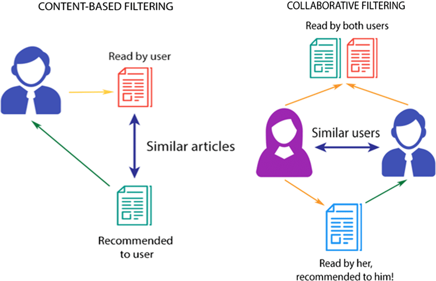

Collaborative and Content-Based Filtering Algorithms

Additionally, I would like to touch base on another topic, **Content-Based Filtering**. Goodreads may also utilize content-based filtering algorithms, which recommend items similar to those the user has already liked or interacted with. This approach considers the characteristics of the items themselves, such as genre, author, and content, to make recommendations.

## How good are Goodreads algorithms?

In exploring the efficacy of Goodreads’ algorithms, particularly the “Readers Also Enjoyed” feature, I encountered an insightful [blog](https://bookriot.com/goodreads-readers-also-enjoyed-feature/) [4] where an avid reader conducted an informal performance test. The blogger suggests that while the algorithm excels at identifying popular books within a genre, it may not finely tune recommendations based on the nuanced characteristics of a reader’s favored titles. This could lead to the suggestion of well-liked books that share a genre but not necessarily the unique qualities that a user might appreciate in a book.

Despite this, the blogger acknowledges the algorithm’s overall success, as evidenced by their high ratings for books recommended by Goodreads. This positive outcome underscores the platform’s reputation among its users for providing quality recommendations, even if there’s room for refinement in capturing individual tastes.

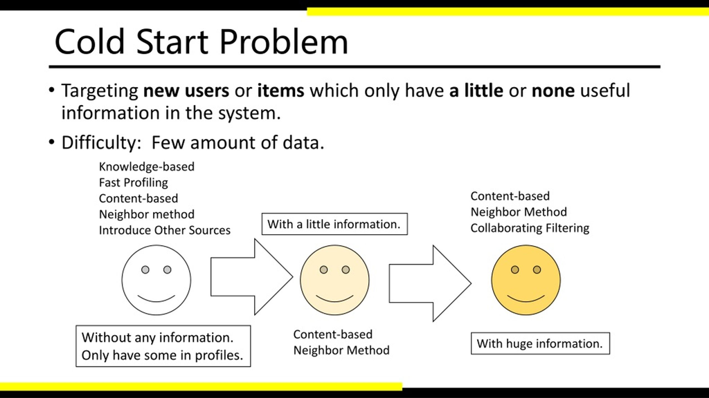

Another issue with the Goodreads is an issue known as **Cold Start Problem**. This seems to be one of the primary challenges for Goodreads, especially for new users, is the cold start problem. This occurs when the recommendation system lacks sufficient data about a user’s preferences and behaviors to make accurate recommendations. Goodreads may struggle to provide relevant suggestions until users have rated a significant number of books. i.e, 20 books.

I also came across another terms when delve intn the Goodreads potential issues, **Limited Diversity and Serendipity**. Goodreads’ recommendation system may exhibit a tendency to recommend popular or mainstream books, potentially limiting the diversity and serendipity of recommendations. Users may miss out on discovering lesser-known or niche titles that align with their interests but are not widely recognized.

## Any Recommendations

1. **Incorporate Sentiment Analysis**:
   - Goodreads could integrate sentiment analysis into its recommendation system to better understand users’ emotional responses to books. By analyzing user reviews for sentiment, the system could identify books that resonate with readers on a deeper level, leading to more personalized and impactful recommendations. This enhancement could enhance user engagement and satisfaction by recommending books that evoke strong emotional connections.
2. **Expand Feature-Based Recommendations**:
   - Goodreads can expand its feature-based recommendations beyond genre and author to include more diverse attributes such as writing style, narrative structure, themes, and character development. By considering a broader range of features, the recommendation system can offer more nuanced and tailored suggestions that align with users’ specific preferences and reading tastes. This enhancement could enhance user discovery and exploration by introducing them to books that resonate with their unique interests and preferences.
3. **Integrate Advanced Machine Learning Models**:
   - Goodreads can leverage advanced machine learning models such as deep learning and natural language processing to improve the accuracy and relevance of its recommendations. These models can analyze complex patterns and relationships in user data and book content to generate more sophisticated and personalized recommendations. By incorporating advanced machine learning techniques, Goodreads can enhance the effectiveness of its recommendation system and provide users with highly relevant and engaging book suggestions.
   - Study “[Enhancing Book Recommendation in Goodreads,](https://link.springer.com/chapter/10.1007/978-3-031-54376-0_36)[7]” indicates that machine learning models like Random Forest and Support Vector Classifier could significantly improve recommendation quality, suggesting a promising direction for Goodreads’ algorithmic development.

## Conclusion

Recommender systems are pivotal to e-commerce, influencing giants and retailers alike. These algorithms are a boon for users with unique tastes, though their effectiveness is still debated.

[figure not shown]

This study explored Goodreads’ recommender system, a leading platform for book enthusiasts. Despite limited details on its algorithm, it’s clear that collaborative filtering is a key component. Critiques suggest a tendency towards generalization, especially in the “Readers Also Enjoyed” section, yet the system reliably curates books aligned with users’ interests.

With AI’s rapid advancement, incorporating sophisticated algorithms like Random Forest could further refine Goodreads’ recommendations. This exploration underscores the critical role of recommender systems in today’s economy and the ample opportunities for AI to enhance them.

## References & Citations

1. https://www.iteratorshq.com/blog/an-introduction-recommender-systems-9-easy-examples/
2. [Goodreads - Wikipedia](https://en.wikipedia.org/wiki/Goodreads)
3. https://help.goodreads.com/s/announcements/a031H00000OfUjVQAV/helpful-goodreads-hack-finding-book-recommendations
4. https://bookriot.com/goodreads-readers-also-enjoyed-feature/
5. [<Reliable Book Recommender System: An Evaluation and Comparison of Collaborative Filtering Algorithms | SpringerLink>](https://link.springer.com/chapter/10.1007/978-3-030-90055-7_20)
6. <[Help:(goodreads.com)](https://help.goodreads.com/s/article/How-do-I-change-my-reading-challenge-goal)>
7. [Enhancing Book Recommendations on GoodReads: A Data Mining Approach Based Random Forest Classification | SpringerLink](https://link.springer.com/chapter/10.1007/978-3-031-54376-0_36)